# PLS - Hoteles

Artículo 1, versión 6 (Doctoranda Moreno)

Roberto Gil-Saura

2021-06-25

## 0.1 Muestra

# 1 Análisis del modelo de medida, multigrupo.

Seguidamente mostramos el modelo estructural (*inner model*), establecidos a partir de las hipótesis lanzadas. A lo largo del documento se muestra el modelo general y el modelo multigrupo generado a partir de variable VALOR RELACIONAL. Sobre la misma se ha generado una clasificación entre ALTA y BAJA, utilizando el criterio de la mediana para realizar la partición.

El modelo estructural es el siguiente:

## 1.1 Constructo

[interactive chart not shown]

Modelo estructural

## 1.2 Fiabilidad del instrumento de medida

Para el modelo de medida se han considerado constructos de tipo composite mode_A (reflectivos). De este modo, el primer paso debe ser observar el resumen de los indicadores de fiabilidad, consistencia interna y validez.

Comenzamos viendo el *Cronbach’s alpha*, y el resultado del análisis muestra todas las escalas que apoyan las variables latentes tienen un mayor que 0.7, completado por una fiabilidad del compuesto *rhoC* también por encima de 0.7. para valores superiores a 0.9[^1].

```
Modelo
```

```
    alpha  rhoC   AVE  rhoA
ICT 0.855 0.903 0.700 0.865
COR 0.892 0.913 0.541 0.903
SUS 0.739 0.848 0.656 0.852
BEQ 0.954 0.966 0.878 0.960
SST 0.856 0.913 0.777 0.870
EST 0.825 0.896 0.742 0.833

Alpha, rhoC, and rhoA should exceed 0.7 while AVE should exceed 0.5
```

```
Modelo grupo 1
```

```
    alpha  rhoC   AVE  rhoA
ICT 0.851 0.900 0.694 0.860
COR 0.909 0.925 0.581 0.916
SUS 0.738 0.837 0.646 0.919
BEQ 0.969 0.977 0.915 0.977
SST 0.893 0.934 0.825 0.899
EST 0.900 0.937 0.833 0.903

Alpha, rhoC, and rhoA should exceed 0.7 while AVE should exceed 0.5
```

```
Modelo grupo 2
```

```
    alpha  rhoC   AVE  rhoA
ICT 0.854 0.902 0.699 0.874
COR 0.870 0.897 0.500 0.890
SUS 0.735 0.847 0.651 0.793
BEQ 0.944 0.959 0.855 0.965
SST 0.805 0.884 0.718 0.838
EST 0.738 0.851 0.656 0.752

Alpha, rhoC, and rhoA should exceed 0.7 while AVE should exceed 0.5
```

## 1.3 Validez convergente

### 1.3.1 AVE (constructos reflectivos)

Del mismo modo, para evaluar la *validez convergente* o grado con el que una medida correlaciona positivamente con medidas alternativas del mismo constructo, usamos el coeficiente *AVE (average variance extracted)* que también cumple con la expectativa de estar por encima de 0.5.

El AVE (*average variance extracted*) se define como la cantidad de varianza que un constructo obtiene de sus indicadores con relación a la cantidad de varianza debida al error de medida, recomendándose que su valor sea superior a 0,50 lo que implica que más del 50% de la varianza del constructo es debida a sus indicadores (Fornell y Larcker, 1981).

```
Modelo
```

```
  ICT   COR   SUS   BEQ   SST   EST
0.700 0.541 0.656 0.878 0.777 0.742
```

```
Modelo grupo 1
```

```
  ICT   COR   SUS   BEQ   SST   EST
0.694 0.581 0.646 0.915 0.825 0.833
```

```
Modelo grupo 2
```

```
  ICT   COR   SUS   BEQ   SST   EST
0.699 0.500 0.651 0.855 0.718 0.656
```

Los indicadores son mostrados de forma conjunta en el siguiente gráfico.

```
Modelo
```

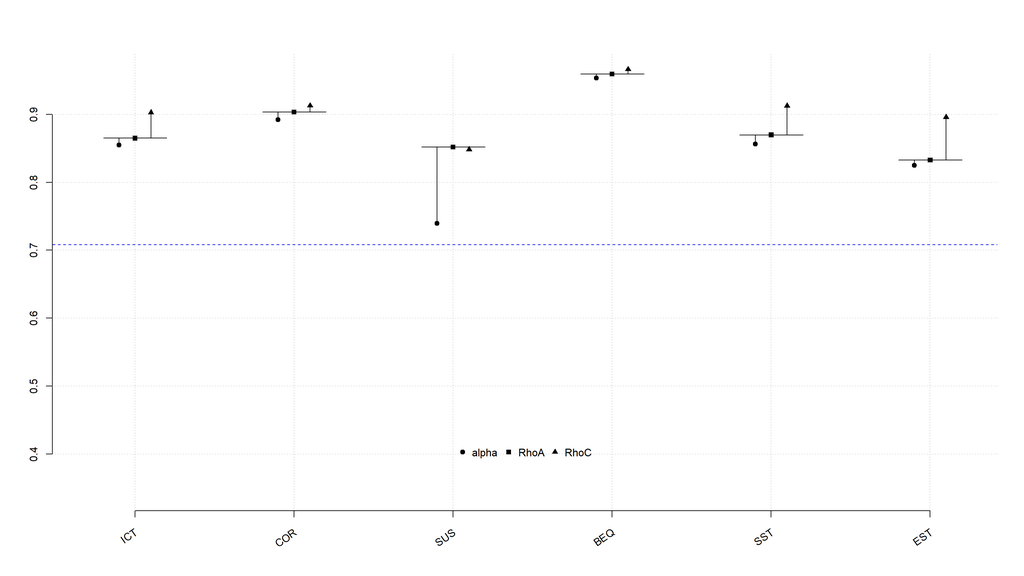

Tabla de fiabilidad

```
Modelo grupo 1
```

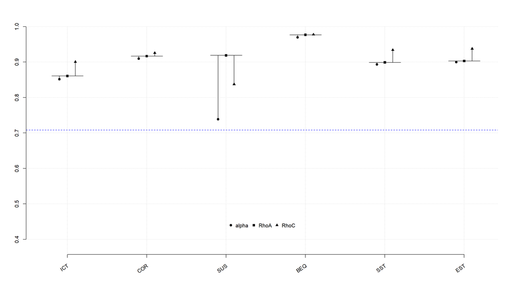

Tabla de fiabilidad

```
Modelo grupo 2
```

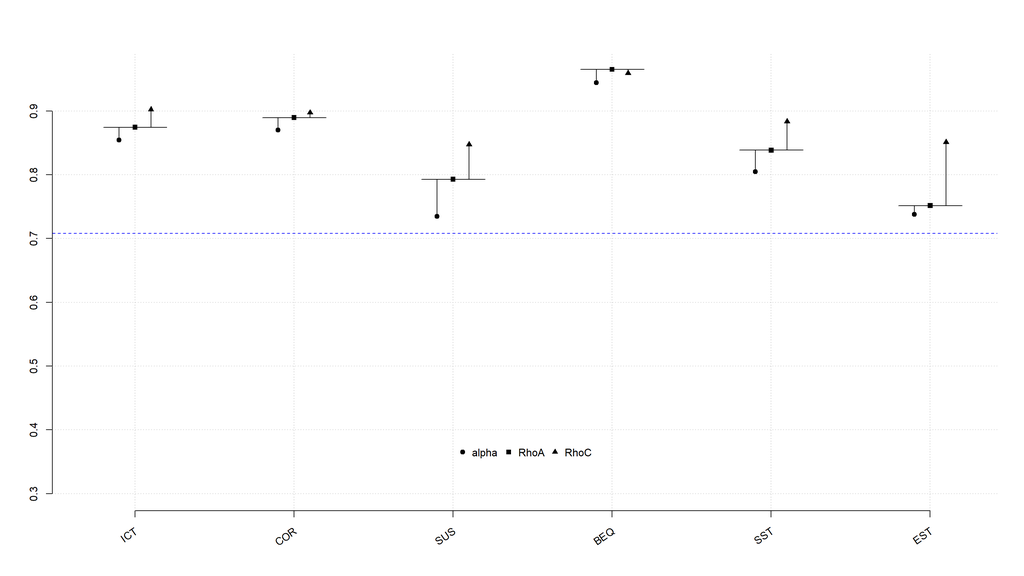

Tabla de fiabilidad

### 1.3.2 Análisis de las cargas (reflectivos) o de los pesos (formativos)

Para la valoración de la validez convergente se analiza también el tamaño de las cargas de los indicadores. El tamaño de las cargas también es considerado un indicador de fiabilidad; es por ello que todas las cargas de todos los indicadores deberían ser estadísticamente significativas y además su tamaño ser igual o superior[^2] al valor 0,708. Las cargas elevadas sobre un constructo, señalan que los indicadores asociados con el mismo tienen mucho en común y, por lo tanto, capturan correctamente la variable latente. Para aquellas cargas que están entre 0.4 y 0.7 debe ser analizado el comportamiento del constructo ante una eliminación del indicador con carga baja[^3].

```
Modelo
```

```
        ICT   COR   SUS   BEQ   SST   EST
ICT1  0.854 0.000 0.000 0.000 0.000 0.000
ICT2  0.893 0.000 0.000 0.000 0.000 0.000
ICT3  0.863 0.000 0.000 0.000 0.000 0.000
ICT4  0.727 0.000 0.000 0.000 0.000 0.000
COR1  0.000 0.707 0.000 0.000 0.000 0.000
COR2  0.000 0.856 0.000 0.000 0.000 0.000
COR3  0.000 0.756 0.000 0.000 0.000 0.000
COR4  0.000 0.802 0.000 0.000 0.000 0.000
COR5  0.000 0.783 0.000 0.000 0.000 0.000
COR6  0.000 0.548 0.000 0.000 0.000 0.000
COR7  0.000 0.640 0.000 0.000 0.000 0.000
COR8  0.000 0.713 0.000 0.000 0.000 0.000
COR9  0.000 0.772 0.000 0.000 0.000 0.000
SUSA  0.000 0.000 0.851 0.000 0.000 0.000
SUSB  0.000 0.000 0.914 0.000 0.000 0.000
SUSC  0.000 0.000 0.640 0.000 0.000 0.000
BEQ7  0.000 0.000 0.000 0.902 0.000 0.000
BEQ8  0.000 0.000 0.000 0.941 0.000 0.000
BEQ9  0.000 0.000 0.000 0.953 0.000 0.000
BEQ10 0.000 0.000 0.000 0.951 0.000 0.000
SST1  0.000 0.000 0.000 0.000 0.821 0.000
SST2  0.000 0.000 0.000 0.000 0.929 0.000
SST3  0.000 0.000 0.000 0.000 0.892 0.000
EST1  0.000 0.000 0.000 0.000 0.000 0.858
EST2  0.000 0.000 0.000 0.000 0.000 0.904
EST3  0.000 0.000 0.000 0.000 0.000 0.819
```

```
Modelo grupo 1
```

```
        ICT   COR   SUS    BEQ   SST   EST
ICT1  0.849 0.000 0.000  0.000 0.000 0.000
ICT2  0.888 0.000 0.000  0.000 0.000 0.000
ICT3  0.847 0.000 0.000  0.000 0.000 0.000
ICT4  0.741 0.000 0.000  0.000 0.000 0.000
COR1  0.000 0.714 0.000  0.000 0.000 0.000
COR2  0.000 0.862 0.000  0.000 0.000 0.000
COR3  0.000 0.811 0.000  0.000 0.000 0.000
COR4  0.000 0.767 0.000  0.000 0.000 0.000
COR5  0.000 0.756 0.000  0.000 0.000 0.000
COR6  0.000 0.669 0.000  0.000 0.000 0.000
COR7  0.000 0.670 0.000  0.000 0.000 0.000
COR8  0.000 0.793 0.000  0.000 0.000 0.000
COR9  0.000 0.797 0.000  0.000 0.000 0.000
SUSA  0.000 0.000 0.903  0.000 0.000 0.000
SUSB  0.000 0.000 0.931  0.000 0.000 0.000
SUSC  0.000 0.000 0.504 -0.000 0.000 0.000
BEQ7  0.000 0.000 0.000  0.938 0.000 0.000
BEQ8  0.000 0.000 0.000  0.941 0.000 0.000
BEQ9  0.000 0.000 0.000  0.975 0.000 0.000
BEQ10 0.000 0.000 0.000  0.972 0.000 0.000
SST1  0.000 0.000 0.000  0.000 0.847 0.000
SST2  0.000 0.000 0.000  0.000 0.944 0.000
SST3  0.000 0.000 0.000  0.000 0.931 0.000
EST1  0.000 0.000 0.000  0.000 0.000 0.920
EST2  0.000 0.000 0.000  0.000 0.000 0.939
EST3  0.000 0.000 0.000  0.000 0.000 0.879
```

```
Modelo grupo 2
```

```
         ICT   COR   SUS   BEQ   SST    EST
ICT1   0.850 0.000 0.000 0.000 0.000  0.000
ICT2   0.892 0.000 0.000 0.000 0.000  0.000
ICT3   0.885 0.000 0.000 0.000 0.000 -0.000
ICT4   0.703 0.000 0.000 0.000 0.000 -0.000
COR1   0.000 0.668 0.000 0.000 0.000  0.000
COR2   0.000 0.837 0.000 0.000 0.000  0.000
COR3   0.000 0.669 0.000 0.000 0.000  0.000
COR4   0.000 0.821 0.000 0.000 0.000  0.000
COR5   0.000 0.807 0.000 0.000 0.000  0.000
COR6   0.000 0.436 0.000 0.000 0.000  0.000
COR7   0.000 0.618 0.000 0.000 0.000  0.000
COR8   0.000 0.660 0.000 0.000 0.000  0.000
COR9   0.000 0.757 0.000 0.000 0.000  0.000
SUSA   0.000 0.000 0.757 0.000 0.000  0.000
SUSB   0.000 0.000 0.894 0.000 0.000  0.000
SUSC   0.000 0.000 0.760 0.000 0.000  0.000
BEQ7   0.000 0.000 0.000 0.890 0.000  0.000
BEQ8   0.000 0.000 0.000 0.946 0.000  0.000
BEQ9   0.000 0.000 0.000 0.929 0.000  0.000
BEQ10  0.000 0.000 0.000 0.933 0.000  0.000
SST1   0.000 0.000 0.000 0.000 0.758  0.000
SST2   0.000 0.000 0.000 0.000 0.904  0.000
SST3   0.000 0.000 0.000 0.000 0.873  0.000
EST1  -0.000 0.000 0.000 0.000 0.000  0.799
EST2   0.000 0.000 0.000 0.000 0.000  0.867
EST3  -0.000 0.000 0.000 0.000 0.000  0.760
```

## 1.4 Validez discriminante

### 1.4.1 Cross-loadings

Para el análisis de la validez discriminante o capacidad de un constructo de ser realmente distinto a otros, utilizamos las denominadas *cross-loadings*, que miden esa capacidad del constructo. En la tabla adjunta se puede observar en cada indicador carga de forma superior en su variable latente, siendo el resto de cargas de menor intensidad.

```
Modelo
```

```
        ICT   COR   SUS   BEQ   SST   EST
ICT1  0.854 0.476 0.361 0.131 0.127 0.081
ICT2  0.893 0.552 0.388 0.234 0.168 0.110
ICT3  0.863 0.525 0.376 0.275 0.110 0.011
ICT4  0.727 0.389 0.370 0.127 0.177 0.051
COR1  0.514 0.707 0.445 0.091 0.229 0.192
COR2  0.463 0.856 0.527 0.094 0.332 0.249
COR3  0.375 0.756 0.457 0.125 0.323 0.165
COR4  0.469 0.802 0.474 0.160 0.239 0.152
COR5  0.399 0.783 0.393 0.218 0.131 0.131
COR6  0.361 0.548 0.245 0.222 0.060 0.091
COR7  0.338 0.640 0.302 0.092 0.124 0.110
COR8  0.523 0.713 0.438 0.294 0.120 0.147
COR9  0.392 0.772 0.447 0.154 0.180 0.183
SUSA  0.377 0.397 0.851 0.168 0.243 0.177
SUSB  0.456 0.613 0.914 0.274 0.336 0.222
SUSC  0.189 0.322 0.640 0.041 0.132 0.116
BEQ7  0.209 0.211 0.239 0.902 0.323 0.336
BEQ8  0.182 0.180 0.160 0.941 0.268 0.277
BEQ9  0.234 0.193 0.208 0.953 0.260 0.276
BEQ10 0.252 0.211 0.234 0.951 0.277 0.248
SST1  0.207 0.218 0.292 0.268 0.821 0.557
SST2  0.139 0.243 0.284 0.239 0.929 0.725
SST3  0.122 0.267 0.259 0.298 0.892 0.738
EST1  0.039 0.192 0.171 0.224 0.629 0.858
EST2  0.118 0.236 0.232 0.245 0.725 0.904
EST3  0.032 0.137 0.164 0.327 0.631 0.819
```

```
Modelo grupo 1
```

```
        ICT   COR   SUS    BEQ   SST   EST
ICT1  0.849 0.511 0.357  0.200 0.126 0.080
ICT2  0.888 0.656 0.424  0.230 0.198 0.178
ICT3  0.847 0.558 0.386  0.196 0.162 0.098
ICT4  0.741 0.404 0.514  0.123 0.208 0.102
COR1  0.539 0.714 0.502  0.150 0.254 0.233
COR2  0.503 0.862 0.453  0.107 0.277 0.219
COR3  0.458 0.811 0.441  0.174 0.339 0.193
COR4  0.477 0.767 0.395  0.223 0.225 0.086
COR5  0.403 0.756 0.294  0.152 0.081 0.131
COR6  0.456 0.669 0.292  0.226 0.055 0.060
COR7  0.377 0.670 0.350  0.016 0.109 0.167
COR8  0.625 0.793 0.392  0.262 0.165 0.156
COR9  0.536 0.797 0.414  0.128 0.154 0.220
SUSA  0.475 0.407 0.903  0.195 0.215 0.117
SUSB  0.506 0.570 0.931  0.290 0.345 0.293
SUSC  0.025 0.136 0.504 -0.042 0.154 0.095
BEQ7  0.237 0.211 0.241  0.938 0.439 0.418
BEQ8  0.150 0.220 0.217  0.941 0.369 0.300
BEQ9  0.252 0.189 0.236  0.975 0.372 0.284
BEQ10 0.225 0.189 0.252  0.972 0.347 0.268
SST1  0.306 0.192 0.318  0.438 0.847 0.619
SST2  0.194 0.281 0.288  0.294 0.944 0.756
SST3  0.086 0.219 0.254  0.372 0.931 0.789
EST1  0.076 0.198 0.161  0.209 0.668 0.920
EST2  0.134 0.244 0.252  0.297 0.759 0.939
EST3  0.170 0.159 0.219  0.408 0.751 0.879
```

```
Modelo grupo 2
```

```
         ICT   COR   SUS   BEQ   SST    EST
ICT1   0.850 0.417 0.351 0.090 0.050  0.043
ICT2   0.892 0.442 0.361 0.242 0.076  0.014
ICT3   0.885 0.510 0.395 0.326 0.046 -0.065
ICT4   0.703 0.359 0.253 0.134 0.109 -0.023
COR1   0.473 0.668 0.385 0.047 0.119  0.102
COR2   0.404 0.837 0.584 0.092 0.310  0.231
COR3   0.280 0.669 0.442 0.089 0.229  0.080
COR4   0.437 0.821 0.522 0.119 0.169  0.165
COR5   0.379 0.807 0.485 0.273 0.124  0.092
COR6   0.279 0.436 0.204 0.226 0.003  0.084
COR7   0.302 0.618 0.266 0.143 0.101  0.044
COR8   0.450 0.660 0.486 0.318 0.055  0.124
COR9   0.271 0.757 0.487 0.178 0.163  0.121
SUSA   0.273 0.334 0.757 0.159 0.177  0.179
SUSB   0.393 0.631 0.894 0.277 0.248  0.104
SUSC   0.311 0.497 0.760 0.106 0.100  0.128
BEQ7   0.204 0.232 0.271 0.890 0.272  0.297
BEQ8   0.223 0.172 0.157 0.946 0.233  0.291
BEQ9   0.221 0.194 0.203 0.929 0.164  0.275
BEQ10  0.266 0.224 0.227 0.933 0.216  0.226
SST1   0.048 0.144 0.176 0.138 0.758  0.461
SST2   0.029 0.112 0.173 0.217 0.904  0.682
SST3   0.118 0.276 0.219 0.255 0.873  0.692
EST1  -0.015 0.155 0.137 0.243 0.585  0.799
EST2   0.062 0.171 0.150 0.214 0.671  0.867
EST3  -0.093 0.087 0.095 0.276 0.525  0.760
```

### 1.4.2 Fornell-Larcker

El criterio de Fornell-Larcker, compara la raíz cuadrado del *AVE* con la correlación de las variables latentes. La raíz cuadrada del *AVE* de cada constructo, debería ser más grande que la más alta correlación con cualquier otro constructo. Se puede observar en la tabla siguiente que el valor en la diagonal principal, es mayor que el resto de valores en la parte inferior de la matriz.

```
Modelo
```

```
      ICT   COR   SUS   BEQ   SST   EST
ICT 0.837     .     .     .     .     .
COR 0.585 0.736     .     .     .     .
SUS 0.446 0.576 0.810     .     .     .
BEQ 0.234 0.213 0.227 0.937     .     .
SST 0.173 0.276 0.313 0.304 0.882     .
EST 0.076 0.221 0.221 0.307 0.770 0.861

FL Criteria table reports square root of AVE on the diagonal and construct correlations on the lower triangle.
```

```
Modelo grupo 1
```

```
      ICT   COR   SUS   BEQ   SST   EST
ICT 0.833     .     .     .     .     .
COR 0.647 0.762     .     .     .     .
SUS 0.504 0.525 0.804     .     .     .
BEQ 0.227 0.212 0.247 0.957     .     .
SST 0.210 0.255 0.314 0.403 0.908     .
EST 0.141 0.220 0.233 0.338 0.798 0.913

FL Criteria table reports square root of AVE on the diagonal and construct correlations on the lower triangle.
```

```
Modelo grupo 2
```

```
       ICT   COR   SUS   BEQ   SST   EST
ICT  0.836     .     .     .     .     .
COR  0.521 0.707     .     .     .     .
SUS  0.412 0.630 0.807     .     .     .
BEQ  0.247 0.225 0.236 0.925     .     .
SST  0.080 0.214 0.224 0.247 0.847     .
EST -0.011 0.173 0.159 0.297 0.737 0.810

FL Criteria table reports square root of AVE on the diagonal and construct correlations on the lower triangle.
```

### 1.4.3 HTMT

Por último el HTMT es un ratio que si es mayor que 0.90 indica una pérdida de validez discriminante. El ratio HTMT nos indica que los indicadores que pertenecen a una determinada variables latente están correlacionando más como otra variable latente que con la propia. HT/MT> 0.85 Clark & Watson, > 0.90 Gold et al. 2001; Teo et al. 2008).

```
Modelo
```

```
      ICT   COR   SUS   BEQ   SST EST
ICT     .     .     .     .     .   .
COR 0.662     .     .     .     .   .
SUS 0.531 0.663     .     .     .   .
BEQ 0.254 0.237 0.233     .     .   .
SST 0.210 0.301 0.370 0.334     .   .
EST 0.098 0.248 0.269 0.344 0.907   .
```

```
Modelo grupo 1
```

```
      ICT   COR   SUS   BEQ   SST EST
ICT     .     .     .     .     .   .
COR 0.718     .     .     .     .   .
SUS 0.568 0.550     .     .     .   .
BEQ 0.246 0.226 0.257     .     .   .
SST 0.246 0.270 0.363 0.432     .   .
EST 0.155 0.239 0.252 0.351 0.884   .
```

```
Modelo grupo 2
```

```
      ICT   COR   SUS   BEQ   SST EST
ICT     .     .     .     .     .   .
COR 0.599     .     .     .     .   .
SUS 0.503 0.735     .     .     .   .
BEQ 0.264 0.257 0.263     .     .   .
SST 0.114 0.251 0.281 0.265     .   .
EST 0.109 0.213 0.227 0.358 0.930   .
```

# 2 Análisis del modelo estructural

- Paths o cargas de latentes…
- R<sup>2</sup>, coeficiente de determinación y/o % de varianza explicada
- f<sup>2</sup> y q<sup>2</sup> efecto tamaño
- Q<sup>2</sup>, relevancia predictiva

## 2.1 Paths y R<sup>2</sup>

```
Modelo
```

```
         COR   SUS   SST   EST
R^2    0.342 0.350 0.164 0.594
AdjR^2 0.340 0.345 0.154 0.592
ICT    0.585 0.166     .     .
COR        . 0.479 0.114     .
SUS        .     . 0.194     .
BEQ        .     . 0.235     .
SST        .     .     . 0.770
```

```
Modelo grupo 1
```

```
         COR   SUS   SST   EST
R^2    0.418 0.322 0.216 0.637
AdjR^2 0.413 0.309 0.195 0.634
ICT    0.647 0.282     .     .
COR        . 0.342 0.086     .
SUS        .     . 0.185     .
BEQ        .     . 0.339     .
SST        .     .     . 0.798
```

```
Modelo grupo 2
```

```
         COR   SUS   SST   EST
R^2    0.272 0.406 0.096 0.543
AdjR^2 0.267 0.398 0.078 0.540
ICT    0.521 0.116     .     .
COR        . 0.569 0.097     .
SUS        .     . 0.116     .
BEQ        .     . 0.198     .
SST        .     .     . 0.737
```

## 2.2 f² - Tamaño del efecto

El f² permite evaluar la contribución de cada constructo exógeno a la R² de un constructo endógeno. Los valores de 0.02, 0.15 y 0.35 indican un efecto pequeño, mediano o grande sobre el constructo endógeno.

```
Modelo
```

```
      ICT   COR   SUS   BEQ   SST   EST
ICT 0.000 0.521 0.026 0.000 0.000 0.000
COR 0.000 0.000 0.228 0.000 0.010 0.000
SUS 0.000 0.000 0.000 0.000 0.030 0.000
BEQ 0.000 0.000 0.000 0.000 0.062 0.000
SST 0.000 0.000 0.000 0.000 0.000 1.461
EST 0.000 0.000 0.000 0.000 0.000 0.000
```

```
Modelo grupo 1
```

```
      ICT   COR   SUS   BEQ   SST   EST
ICT 0.000 0.718 0.073 0.000 0.000 0.000
COR 0.000 0.000 0.088 0.000 0.006 0.000
SUS 0.000 0.000 0.000 0.000 0.031 0.000
BEQ 0.000 0.000 0.000 0.000 0.136 0.000
SST 0.000 0.000 0.000 0.000 0.000 1.753
EST 0.000 0.000 0.000 0.000 0.000 0.000
```

```
Modelo grupo 2
```

```
      ICT   COR   SUS   BEQ   SST   EST
ICT 0.000 0.373 0.014 0.000 0.000 0.000
COR 0.000 0.000 0.402 0.000 0.006 0.000
SUS 0.000 0.000 0.000 0.000 0.009 0.000
BEQ 0.000 0.000 0.000 0.000 0.041 0.000
SST 0.000 0.000 0.000 0.000 0.000 1.189
EST 0.000 0.000 0.000 0.000 0.000 0.000
```

## 2.3 Efectos

### 2.3.1 Totales

```
Modelo
```

```
      ICT   COR   SUS   BEQ   SST   EST
ICT 0.000 0.585 0.446 0.000 0.153 0.118
COR 0.000 0.000 0.479 0.000 0.207 0.160
SUS 0.000 0.000 0.000 0.000 0.194 0.150
BEQ 0.000 0.000 0.000 0.000 0.235 0.181
SST 0.000 0.000 0.000 0.000 0.000 0.770
EST 0.000 0.000 0.000 0.000 0.000 0.000
```

```
Modelo grupo 1
```

```
      ICT   COR   SUS   BEQ   SST   EST
ICT 0.000 0.647 0.504 0.000 0.149 0.119
COR 0.000 0.000 0.342 0.000 0.149 0.119
SUS 0.000 0.000 0.000 0.000 0.185 0.148
BEQ 0.000 0.000 0.000 0.000 0.339 0.270
SST 0.000 0.000 0.000 0.000 0.000 0.798
EST 0.000 0.000 0.000 0.000 0.000 0.000
```

```
Modelo grupo 2
```

```
      ICT   COR   SUS   BEQ   SST   EST
ICT 0.000 0.521 0.412 0.000 0.098 0.072
COR 0.000 0.000 0.569 0.000 0.163 0.120
SUS 0.000 0.000 0.000 0.000 0.116 0.085
BEQ 0.000 0.000 0.000 0.000 0.198 0.146
SST 0.000 0.000 0.000 0.000 0.000 0.737
EST 0.000 0.000 0.000 0.000 0.000 0.000
```

### 2.3.2 Indirectos

```
Modelo
```

```
      ICT   COR   SUS   BEQ   SST   EST
ICT 0.000 0.000 0.280 0.000 0.153 0.118
COR 0.000 0.000 0.000 0.000 0.093 0.160
SUS 0.000 0.000 0.000 0.000 0.000 0.150
BEQ 0.000 0.000 0.000 0.000 0.000 0.181
SST 0.000 0.000 0.000 0.000 0.000 0.000
EST 0.000 0.000 0.000 0.000 0.000 0.000
```

```
Modelo grupo 1
```

```
      ICT   COR   SUS   BEQ   SST   EST
ICT 0.000 0.000 0.221 0.000 0.149 0.119
COR 0.000 0.000 0.000 0.000 0.063 0.119
SUS 0.000 0.000 0.000 0.000 0.000 0.148
BEQ 0.000 0.000 0.000 0.000 0.000 0.270
SST 0.000 0.000 0.000 0.000 0.000 0.000
EST 0.000 0.000 0.000 0.000 0.000 0.000
```

```
Modelo grupo 2
```

```
      ICT   COR   SUS   BEQ   SST   EST
ICT 0.000 0.000 0.297 0.000 0.098 0.072
COR 0.000 0.000 0.000 0.000 0.066 0.120
SUS 0.000 0.000 0.000 0.000 0.000 0.085
BEQ 0.000 0.000 0.000 0.000 0.000 0.146
SST 0.000 0.000 0.000 0.000 0.000 0.000
EST 0.000 0.000 0.000 0.000 0.000 0.000
```

### 2.3.3 it_criteria

```
Modelo
```

```
         COR      SUS     SST      EST
AIC -109.307 -110.513 -40.989 -238.359
BIC -102.126  -99.740 -26.625 -231.177
```

```
Modelo grupo 1
```

```
        COR     SUS     SST      EST
AIC -58.175 -38.875 -20.537 -111.453
BIC -52.720 -30.693  -9.627 -105.998
```

```
Modelo grupo 2
```

```
        COR     SUS    SST      EST
AIC -46.169 -75.793 -8.584 -118.452
BIC -40.082 -66.663  3.590 -112.365
```

# 3 Modelización con bootstrapping

*Bootstrapping* para calcular la significatividad de los paths estimados y del resto de elementos que usamos para la validación. Habitualmente se trabaja con un 5% (t > 1.96) lo que implica significatividad al 95%. Podemos cambiar al 10 o al 1 según ámbito. Usar doble *bootstrapping* si hay menos de 4 constructos.

## 3.1 Bootstrapped Structural paths

Conjunto de coeficiente path con intervalo de confianza. Los intervalos de confianza no deben contener el 0 para ser significativos.

```
Modelo
```

```
             Original Est. Bootstrap Mean Bootstrap SD T Stat. 2.5% CI 97.5% CI
ICT  ->  COR         0.585          0.588        0.040  14.551   0.506    0.661
ICT  ->  SUS         0.166          0.167        0.058   2.870   0.050    0.278
COR  ->  SUS         0.479          0.483        0.060   8.014   0.361    0.595
COR  ->  SST         0.114          0.112        0.067   1.691  -0.021    0.239
SUS  ->  SST         0.194          0.196        0.059   3.315   0.083    0.309
BEQ  ->  SST         0.235          0.238        0.061   3.879   0.121    0.359
SST  ->  EST         0.770          0.773        0.034  22.793   0.703    0.833
```

```
Modelo grupo 1
```

```
             Original Est. Bootstrap Mean Bootstrap SD T Stat. 2.5% CI 97.5% CI
ICT  ->  COR         0.647          0.653        0.058  11.168   0.528    0.752
ICT  ->  SUS         0.282          0.283        0.098   2.873   0.084    0.475
COR  ->  SUS         0.342          0.351        0.102   3.361   0.131    0.534
COR  ->  SST         0.086          0.080        0.097   0.882  -0.117    0.264
SUS  ->  SST         0.185          0.193        0.079   2.330   0.042    0.352
BEQ  ->  SST         0.339          0.337        0.089   3.791   0.159    0.510
SST  ->  EST         0.798          0.798        0.050  15.995   0.690    0.884
```

```
Modelo grupo 2
```

```
             Original Est. Bootstrap Mean Bootstrap SD T Stat. 2.5% CI 97.5% CI
ICT  ->  COR         0.521          0.527        0.053   9.886   0.418    0.624
ICT  ->  SUS         0.116          0.119        0.076   1.524  -0.037    0.259
COR  ->  SUS         0.569          0.573        0.072   7.942   0.430    0.713
COR  ->  SST         0.097          0.099        0.102   0.951  -0.100    0.295
SUS  ->  SST         0.116          0.116        0.105   1.108  -0.088    0.321
BEQ  ->  SST         0.198          0.206        0.080   2.492   0.056    0.363
SST  ->  EST         0.737          0.745        0.043  17.334   0.656    0.822
```

## 3.2 Bootstrapped loadings

Cargas (modelo con constructos reflectivos) con intervalo de confianza. Las cargas deberían ser significativas y mayores a 0.708 dado que este número al cuadrado es 0.50 (Hair et al. 2017).

```
Modelo
```

```
               Original Est. Bootstrap Mean Bootstrap SD T Stat. 2.5% CI 97.5% CI
ICT1  ->  ICT          0.854          0.853        0.022  38.209   0.803    0.892
ICT2  ->  ICT          0.893          0.893        0.015  59.529   0.860    0.919
ICT3  ->  ICT          0.863          0.862        0.019  44.954   0.821    0.896
ICT4  ->  ICT          0.727          0.723        0.038  18.879   0.641    0.790
COR1  ->  COR          0.707          0.705        0.035  20.127   0.634    0.769
COR2  ->  COR          0.856          0.855        0.018  46.294   0.816    0.889
COR3  ->  COR          0.756          0.755        0.039  19.443   0.671    0.822
COR4  ->  COR          0.802          0.801        0.028  28.892   0.743    0.852
COR5  ->  COR          0.783          0.782        0.025  31.550   0.730    0.826
COR6  ->  COR          0.548          0.547        0.053  10.323   0.437    0.644
COR7  ->  COR          0.640          0.641        0.057  11.227   0.519    0.740
COR8  ->  COR          0.713          0.713        0.039  18.299   0.628    0.780
COR9  ->  COR          0.772          0.772        0.027  29.130   0.714    0.820
SUSA  ->  SUS          0.851          0.848        0.032  26.780   0.778    0.900
SUSB  ->  SUS          0.914          0.914        0.012  76.863   0.889    0.935
SUSC  ->  SUS          0.640          0.637        0.059  10.860   0.508    0.741
BEQ7  ->  BEQ          0.902          0.903        0.021  43.601   0.860    0.940
BEQ8  ->  BEQ          0.941          0.940        0.016  57.262   0.901    0.966
BEQ9  ->  BEQ          0.953          0.951        0.015  65.414   0.917    0.973
BEQ10  ->  BEQ         0.951          0.950        0.014  68.862   0.919    0.972
SST1  ->  SST          0.821          0.820        0.035  23.402   0.744    0.879
SST2  ->  SST          0.929          0.928        0.013  72.831   0.901    0.950
SST3  ->  SST          0.892          0.892        0.020  45.736   0.848    0.924
EST1  ->  EST          0.858          0.858        0.031  27.701   0.789    0.909
EST2  ->  EST          0.904          0.904        0.017  53.029   0.865    0.931
EST3  ->  EST          0.819          0.819        0.028  29.214   0.757    0.869
```

```
Modelo grupo 1
```

```
               Original Est. Bootstrap Mean Bootstrap SD T Stat. 2.5% CI 97.5% CI
ICT1  ->  ICT          0.849          0.846        0.036  23.718   0.765    0.904
ICT2  ->  ICT          0.888          0.888        0.022  39.887   0.839    0.924
ICT3  ->  ICT          0.847          0.843        0.040  21.346   0.754    0.906
ICT4  ->  ICT          0.741          0.735        0.057  13.115   0.613    0.830
COR1  ->  COR          0.714          0.713        0.053  13.513   0.600    0.804
COR2  ->  COR          0.862          0.861        0.027  31.577   0.799    0.907
COR3  ->  COR          0.811          0.810        0.061  13.335   0.669    0.898
COR4  ->  COR          0.767          0.765        0.048  15.902   0.657    0.846
COR5  ->  COR          0.756          0.752        0.044  17.374   0.656    0.826
COR6  ->  COR          0.669          0.668        0.061  10.903   0.533    0.775
COR7  ->  COR          0.670          0.669        0.055  12.208   0.550    0.764
COR8  ->  COR          0.793          0.794        0.036  22.330   0.718    0.856
COR9  ->  COR          0.797          0.799        0.026  30.422   0.742    0.847
SUSA  ->  SUS          0.903          0.897        0.031  28.900   0.821    0.941
SUSB  ->  SUS          0.931          0.929        0.016  57.688   0.893    0.956
SUSC  ->  SUS          0.504          0.502        0.112   4.489   0.246    0.683
BEQ7  ->  BEQ          0.938          0.939        0.015  62.621   0.906    0.964
BEQ8  ->  BEQ          0.941          0.940        0.022  41.990   0.889    0.974
BEQ9  ->  BEQ          0.975          0.975        0.007 141.743   0.959    0.986
BEQ10  ->  BEQ         0.972          0.971        0.008 114.676   0.951    0.984
SST1  ->  SST          0.847          0.845        0.043  19.599   0.745    0.914
SST2  ->  SST          0.944          0.944        0.016  57.608   0.907    0.971
SST3  ->  SST          0.931          0.931        0.015  62.709   0.899    0.957
EST1  ->  EST          0.920          0.918        0.022  41.954   0.867    0.952
EST2  ->  EST          0.939          0.938        0.013  71.204   0.909    0.961
EST3  ->  EST          0.879          0.879        0.030  29.155   0.810    0.928
```

```
Modelo grupo 2
```

```
               Original Est. Bootstrap Mean Bootstrap SD T Stat. 2.5% CI 97.5% CI
ICT1  ->  ICT          0.850          0.849        0.031  27.472   0.781    0.899
ICT2  ->  ICT          0.892          0.891        0.022  40.485   0.841    0.927
ICT3  ->  ICT          0.885          0.884        0.019  46.439   0.841    0.917
ICT4  ->  ICT          0.703          0.697        0.058  12.163   0.567    0.793
COR1  ->  COR          0.668          0.664        0.055  12.094   0.551    0.763
COR2  ->  COR          0.837          0.836        0.029  28.630   0.771    0.886
COR3  ->  COR          0.669          0.670        0.057  11.762   0.549    0.770
COR4  ->  COR          0.821          0.818        0.036  22.597   0.739    0.880
COR5  ->  COR          0.807          0.806        0.027  29.343   0.747    0.855
COR6  ->  COR          0.436          0.432        0.090   4.839   0.248    0.600
COR7  ->  COR          0.618          0.622        0.098   6.299   0.416    0.788
COR8  ->  COR          0.660          0.657        0.071   9.324   0.506    0.780
COR9  ->  COR          0.757          0.754        0.047  15.954   0.647    0.832
SUSA  ->  SUS          0.757          0.753        0.068  11.077   0.592    0.862
SUSB  ->  SUS          0.894          0.896        0.019  46.252   0.857    0.930
SUSC  ->  SUS          0.760          0.756        0.054  14.181   0.633    0.839
BEQ7  ->  BEQ          0.890          0.891        0.063  14.072   0.821    0.952
BEQ8  ->  BEQ          0.946          0.940        0.051  18.493   0.874    0.975
BEQ9  ->  BEQ          0.929          0.920        0.056  16.515   0.825    0.969
BEQ10  ->  BEQ         0.933          0.926        0.054  17.428   0.855    0.970
SST1  ->  SST          0.758          0.756        0.067  11.368   0.605    0.865
SST2  ->  SST          0.904          0.903        0.022  42.015   0.856    0.940
SST3  ->  SST          0.873          0.872        0.028  31.398   0.811    0.918
EST1  ->  EST          0.799          0.799        0.054  14.871   0.680    0.887
EST2  ->  EST          0.867          0.868        0.030  28.826   0.799    0.913
EST3  ->  EST          0.760          0.758        0.049  15.515   0.648    0.838
```

## 3.3 Bootstrapped HTMT

```
Modelo
```

```
             Original Est. Bootstrap Mean Bootstrap SD T Stat. 2.5% CI 97.5% CI
ICT  ->  COR         0.662          0.662        0.044  14.961   0.569    0.742
ICT  ->  SUS         0.531          0.534        0.066   7.995   0.397    0.663
ICT  ->  BEQ         0.254          0.254        0.059   4.330   0.140    0.370
ICT  ->  SST         0.210          0.212        0.058   3.606   0.105    0.329
ICT  ->  EST         0.098          0.127        0.042   2.342   0.064    0.226
COR  ->  SUS         0.663          0.664        0.068   9.686   0.523    0.789
COR  ->  BEQ         0.237          0.242        0.058   4.101   0.138    0.360
COR  ->  SST         0.301          0.308        0.058   5.232   0.200    0.419
COR  ->  EST         0.248          0.257        0.064   3.886   0.140    0.385
SUS  ->  BEQ         0.233          0.248        0.062   3.754   0.134    0.377
SUS  ->  SST         0.370          0.373        0.060   6.113   0.254    0.492
SUS  ->  EST         0.269          0.271        0.072   3.708   0.134    0.419
BEQ  ->  SST         0.334          0.335        0.068   4.914   0.199    0.466
BEQ  ->  EST         0.344          0.345        0.068   5.065   0.211    0.474
SST  ->  EST         0.907          0.908        0.040  22.852   0.830    0.984
```

```
Modelo grupo 1
```

```
             Original Est. Bootstrap Mean Bootstrap SD T Stat. 2.5% CI 97.5% CI
ICT  ->  COR         0.718          0.718        0.064  11.257   0.582    0.829
ICT  ->  SUS         0.568          0.593        0.084   6.742   0.434    0.764
ICT  ->  BEQ         0.246          0.256        0.091   2.708   0.096    0.441
ICT  ->  SST         0.246          0.269        0.075   3.298   0.147    0.434
ICT  ->  EST         0.155          0.188        0.078   1.982   0.077    0.368
COR  ->  SUS         0.550          0.574        0.106   5.212   0.367    0.776
COR  ->  BEQ         0.226          0.245        0.080   2.819   0.119    0.420
COR  ->  SST         0.270          0.292        0.079   3.424   0.157    0.458
COR  ->  EST         0.239          0.261        0.080   2.999   0.133    0.432
SUS  ->  BEQ         0.257          0.285        0.092   2.783   0.120    0.473
SUS  ->  SST         0.363          0.376        0.081   4.459   0.219    0.536
SUS  ->  EST         0.252          0.277        0.082   3.086   0.136    0.446
BEQ  ->  SST         0.432          0.430        0.090   4.783   0.241    0.601
BEQ  ->  EST         0.351          0.352        0.093   3.759   0.173    0.529
SST  ->  EST         0.884          0.883        0.057  15.577   0.760    0.981
```

```
Modelo grupo 2
```

```
             Original Est. Bootstrap Mean Bootstrap SD T Stat. 2.5% CI 97.5% CI
ICT  ->  COR         0.599          0.599        0.058  10.380   0.480    0.708
ICT  ->  SUS         0.503          0.510        0.081   6.194   0.344    0.661
ICT  ->  BEQ         0.264          0.272        0.071   3.712   0.140    0.413
ICT  ->  SST         0.114          0.153        0.047   2.413   0.081    0.266
ICT  ->  EST         0.109          0.164        0.045   2.409   0.088    0.264
COR  ->  SUS         0.735          0.735        0.074   9.958   0.586    0.869
COR  ->  BEQ         0.257          0.275        0.068   3.760   0.155    0.422
COR  ->  SST         0.251          0.278        0.066   3.830   0.166    0.416
COR  ->  EST         0.213          0.255        0.081   2.621   0.134    0.441
SUS  ->  BEQ         0.263          0.276        0.080   3.277   0.138    0.443
SUS  ->  SST         0.281          0.298        0.090   3.122   0.138    0.485
SUS  ->  EST         0.227          0.257        0.101   2.236   0.106    0.482
BEQ  ->  SST         0.265          0.272        0.089   2.966   0.108    0.453
BEQ  ->  EST         0.358          0.359        0.100   3.597   0.168    0.556
SST  ->  EST         0.930          0.939        0.063  14.857   0.818    1.066
```

## 3.4 Bootstrapped total effects

Para la comprobación de los coeficientes b del modelo y conocer que son significativos.

```
Modelo
```

```
             Original Est. Bootstrap Mean Bootstrap SD T Stat. 2.5% CI 97.5% CI
ICT  ->  COR         0.585          0.588        0.040  14.551   0.506    0.661
ICT  ->  SUS         0.446          0.450        0.051   8.698   0.346    0.552
ICT  ->  SST         0.153          0.154        0.036   4.277   0.086    0.227
ICT  ->  EST         0.118          0.119        0.029   4.093   0.066    0.179
COR  ->  SUS         0.479          0.483        0.060   8.014   0.361    0.595
COR  ->  SST         0.207          0.207        0.059   3.522   0.092    0.323
COR  ->  EST         0.160          0.160        0.047   3.405   0.070    0.254
SUS  ->  SST         0.194          0.196        0.059   3.315   0.083    0.309
SUS  ->  EST         0.150          0.152        0.046   3.287   0.064    0.242
BEQ  ->  SST         0.235          0.238        0.061   3.879   0.121    0.359
BEQ  ->  EST         0.181          0.184        0.048   3.759   0.092    0.282
SST  ->  EST         0.770          0.773        0.034  22.793   0.703    0.833
```

```
Modelo grupo 1
```

```
             Original Est. Bootstrap Mean Bootstrap SD T Stat. 2.5% CI 97.5% CI
ICT  ->  COR         0.647          0.653        0.058  11.168   0.528    0.752
ICT  ->  SUS         0.504          0.510        0.081   6.207   0.333    0.654
ICT  ->  SST         0.149          0.151        0.063   2.368   0.024    0.271
ICT  ->  EST         0.119          0.121        0.052   2.279   0.019    0.223
COR  ->  SUS         0.342          0.351        0.102   3.361   0.131    0.534
COR  ->  SST         0.149          0.149        0.094   1.586  -0.040    0.332
COR  ->  EST         0.119          0.120        0.076   1.555  -0.030    0.272
SUS  ->  SST         0.185          0.193        0.079   2.330   0.042    0.352
SUS  ->  EST         0.148          0.154        0.063   2.337   0.034    0.283
BEQ  ->  SST         0.339          0.337        0.089   3.791   0.159    0.510
BEQ  ->  EST         0.270          0.270        0.075   3.605   0.121    0.417
SST  ->  EST         0.798          0.798        0.050  15.995   0.690    0.884
```

```
Modelo grupo 2
```

```
             Original Est. Bootstrap Mean Bootstrap SD T Stat. 2.5% CI 97.5% CI
ICT  ->  COR         0.521          0.527        0.053   9.886   0.418    0.624
ICT  ->  SUS         0.412          0.422        0.060   6.892   0.302    0.535
ICT  ->  SST         0.098          0.100        0.041   2.401   0.021    0.181
ICT  ->  EST         0.072          0.075        0.030   2.409   0.017    0.136
COR  ->  SUS         0.569          0.573        0.072   7.942   0.430    0.713
COR  ->  SST         0.163          0.165        0.077   2.111   0.013    0.315
COR  ->  EST         0.120          0.122        0.057   2.095   0.010    0.235
SUS  ->  SST         0.116          0.116        0.105   1.108  -0.088    0.321
SUS  ->  EST         0.085          0.087        0.078   1.090  -0.064    0.240
BEQ  ->  SST         0.198          0.206        0.080   2.492   0.056    0.363
BEQ  ->  EST         0.146          0.154        0.061   2.412   0.042    0.276
SST  ->  EST         0.737          0.745        0.043  17.334   0.656    0.822
```

# 4 Modelos

Representamos los modelos con su valores de trabajo obtenidos.

## 4.1 Modelo general

```
Modelo
```

[interactive chart not shown]

Modelo con bootstrapping

## 4.2 Modelo grupo 1

```
Modelo grupo 1
```

[interactive chart not shown]

Modelo con bootstrapping

## 4.3 Modelo grupo 2

```
Modelo grupo 2
```

[interactive chart not shown]

Modelo con bootstrapping

# 5 Predicción (seminr)

## 5.1 Modelo general

[output not shown]

```
PLS in-sample metrics:
      COR1  COR2  COR3  COR4  COR5  COR6  COR7  COR8  COR9  SUSA  SUSB  SUSC  SST1  SST2  SST3  EST1  EST2  EST3
RMSE 0.899 0.869 1.040 0.806 1.083 0.787 0.880 0.867 0.950 0.926 0.891 0.986 1.105 1.012 1.181 1.083 1.016 1.303
MAE  0.675 0.683 0.840 0.647 0.927 0.617 0.719 0.703 0.766 0.707 0.728 0.783 0.834 0.776 0.921 0.874 0.804 1.028

PLS out-of-sample metrics:
      COR1  COR2  COR3  COR4  COR5  COR6  COR7  COR8  COR9  SUSA  SUSB  SUSC  SST1  SST2  SST3  EST1  EST2  EST3
RMSE 0.907 0.878 1.048 0.811 1.089 0.790 0.884 0.877 0.954 0.932 0.896 0.990 1.115 1.022 1.193 1.090 1.022 1.313
MAE  0.681 0.691 0.845 0.651 0.930 0.619 0.723 0.709 0.770 0.712 0.732 0.787 0.842 0.785 0.930 0.879 0.810 1.036

LM in-sample metrics:
      COR1  COR2  COR3  COR4  COR5  COR6  COR7  COR8  COR9  SUSA  SUSB  SUSC  SST1  SST2  SST3  EST1  EST2  EST3
RMSE 0.829 0.724 0.886 0.719 0.909 0.730 0.814 0.765 0.842 0.828 0.714 0.910 0.851 0.616 0.718 0.738 0.635 0.947
MAE  0.636 0.547 0.701 0.568 0.763 0.578 0.662 0.607 0.670 0.609 0.558 0.705 0.635 0.462 0.541 0.569 0.459 0.682

LM out-of-sample metrics:
      COR1  COR2  COR3  COR4  COR5  COR6  COR7  COR8  COR9  SUSA  SUSB  SUSC  SST1  SST2  SST3  EST1  EST2  EST3
RMSE 0.915 0.779 0.951 0.793 1.004 0.794 0.894 0.877 0.915 0.983 0.791 1.021 0.971 0.703 0.852 0.866 0.722 1.093
MAE  0.695 0.591 0.753 0.620 0.837 0.628 0.725 0.680 0.723 0.711 0.615 0.788 0.705 0.521 0.621 0.654 0.525 0.762
```

## 5.2 Modelo grupo 1

```
Modelo grupo 1
```

```
PLS in-sample metrics:
      COR1  COR2  COR3  COR4  COR5  COR6  COR7  COR8  COR9  SUSA  SUSB  SUSC  SST1  SST2  SST3  EST1  EST2  EST3
RMSE 0.937 0.937 1.108 0.814 1.108 0.674 0.811 0.793 0.906 0.872 0.862 1.067 1.152 1.074 1.140 1.147 1.072 1.215
MAE  0.723 0.734 0.860 0.641 0.952 0.540 0.660 0.664 0.706 0.691 0.690 0.855 0.928 0.818 0.898 0.905 0.866 0.954

PLS out-of-sample metrics:
      COR1  COR2  COR3  COR4  COR5  COR6  COR7  COR8  COR9  SUSA  SUSB  SUSC  SST1  SST2  SST3  EST1  EST2  EST3
RMSE 0.962 0.974 1.161 0.834 1.131 0.678 0.821 0.797 0.917 0.886 0.887 1.084 1.186 1.094 1.164 1.161 1.085 1.244
MAE  0.741 0.758 0.891 0.657 0.972 0.544 0.669 0.667 0.716 0.702 0.706 0.867 0.945 0.824 0.915 0.914 0.875 0.977

LM in-sample metrics:
      COR1  COR2  COR3  COR4  COR5  COR6  COR7  COR8  COR9  SUSA  SUSB  SUSC  SST1  SST2  SST3  EST1  EST2  EST3
RMSE 0.810 0.781 0.856 0.700 0.744 0.608 0.691 0.694 0.788 0.740 0.674 0.871 0.777 0.609 0.626 0.642 0.601 0.698
MAE  0.639 0.605 0.689 0.551 0.587 0.505 0.551 0.563 0.615 0.578 0.532 0.640 0.606 0.450 0.463 0.503 0.453 0.519

LM out-of-sample metrics:
      COR1  COR2  COR3  COR4  COR5  COR6  COR7  COR8  COR9  SUSA  SUSB  SUSC  SST1  SST2  SST3  EST1  EST2  EST3
RMSE 1.033 1.049 1.127 0.843 0.937 0.763 0.920 0.853 1.012 1.047 0.953 1.161 1.093 0.806 0.855 0.885 0.815 1.020
MAE  0.808 0.787 0.858 0.659 0.735 0.615 0.699 0.658 0.754 0.795 0.748 0.880 0.855 0.601 0.631 0.682 0.619 0.745
```

## 5.3 Modelo grupo 2

```
Modelo grupo 2
```

```
PLS in-sample metrics:
      COR1  COR2  COR3  COR4  COR5  COR6  COR7  COR8  COR9  SUSA  SUSB  SUSC  SST1  SST2  SST3  EST1  EST2  EST3
RMSE 0.847 0.780 0.942 0.780 1.058 0.853 0.925 0.907 0.956 0.917 0.877 0.918 0.936 0.887 1.186 1.023 0.938 1.331
MAE  0.603 0.620 0.799 0.635 0.899 0.670 0.756 0.719 0.791 0.652 0.726 0.728 0.670 0.656 0.925 0.846 0.725 1.054

PLS out-of-sample metrics:
      COR1  COR2  COR3  COR4  COR5  COR6  COR7  COR8  COR9  SUSA  SUSB  SUSC  SST1  SST2  SST3  EST1  EST2  EST3
RMSE 0.862 0.791 0.954 0.790 1.068 0.858 0.929 0.917 0.970 0.932 0.884 0.931 0.949 0.903 1.211 1.032 0.947 1.338
MAE  0.615 0.626 0.809 0.644 0.909 0.673 0.763 0.726 0.802 0.666 0.732 0.734 0.683 0.668 0.945 0.852 0.733 1.061

LM in-sample metrics:
      COR1  COR2  COR3  COR4  COR5  COR6  COR7  COR8  COR9  SUSA  SUSB  SUSC  SST1  SST2  SST3  EST1  EST2  EST3
RMSE 0.757 0.561 0.795 0.652 0.826 0.736 0.826 0.729 0.793 0.776 0.611 0.781 0.704 0.534 0.694 0.661 0.557 0.938
MAE  0.574 0.426 0.650 0.515 0.670 0.592 0.673 0.571 0.625 0.549 0.476 0.620 0.507 0.416 0.543 0.519 0.419 0.686

LM out-of-sample metrics:
      COR1  COR2  COR3  COR4  COR5  COR6  COR7  COR8  COR9  SUSA  SUSB  SUSC  SST1  SST2  SST3  EST1  EST2  EST3
RMSE 0.930 0.677 0.936 0.775 0.966 0.864 0.951 0.867 0.955 1.048 0.756 1.011 0.909 0.746 0.920 0.885 0.709 1.356
MAE  0.694 0.504 0.768 0.604 0.781 0.698 0.779 0.672 0.748 0.741 0.590 0.777 0.643 0.555 0.679 0.674 0.523 0.931
```

# 6 Bibliografía

- Clark, L. y Watson, D. (1995). Constructing validity: basic issues in objective scale development. Psychological Assessment, 7(3):309—319.
- Gold, A. , Malhotra, A. , y Segars, A. (2001). Knowledge management: An organizational capabilities perspective. Journal of Management Information Systems, 18(1):185—214.
- Hair Jr., Joseph F.; G. Tomas M. Hult; Christian M. Ringle; Marko Sarstedt. (2017) A Primer on Partial Least Squares Structural Equation Modeling (PLS-SEM). SAGE Publications. 2ª edición, Kindle.
- Aldás Manzano, J., & Uriel Jimenez, E. (2017). Análisis multivariante aplicado con R. Ediciones Paraninfo, SA.
- Champely, S. (2020). pwr: Basic Functions for Power Analysis. R package version 1.3-0. https://CRAN.R-project.org/package=pwr
- Cohen, J. (1988). Statistical power analysis for the behavioral sciences (2nd ed.). Hillsdale,NJ: Lawrence Erlbaum.
- Chin, W.W., 1998. The partial least squares approach to structural equation modelling. In G. A. Marcoulides (Ed.), Modern methods for business research, 295-336. Mahwah, NJ: Lawrence Erlbaum Associates.
- Demin, Gregory. 2020. Expss: Tables, Labels and Some Useful Functions from Spreadsheets and ‘SPSS’ Statistics. https://CRAN.R-project.org/package=expss.
- Falk, R. F. y Miller, N. B., 1992. A primer for soft modeling. Ohio: University of Akron Press.
- Gold, A., Malhotra, A., y Segars, A. (2001). Knowledge management: An organizational capabilities perspective. Journal of Management Information Systems, 18(1):185—214.
- Gil, R., 2021. Tablas y gráficos con R y R Studio. 1st ed. [ebook] València, ISBN: 978-84-09-29382-7; disponible en: https://tables.investigaonline.com.
- Hair, J.F., Hult, G. T.M., Ringle, C.M., & Sarstedt, M., 2017. A primer on partial least squares structural equation modelling (PLS-SEM) (2nd ed.). Thousand Oaks, CA: Sage.
- Henseler, J., Ringle, C.M., & Sarstedt, M., 2016. Testing measurement invariance of com- posites using partial least squares. International Marketing Review, 33(3), 405-431.
- Joreskog, K.G., 1978. Structural analysis of covariance and correlation matrices. Psychometrika, 43, 443-477.
- R Core Team (2021). R: A language and environment for statistical computing. R Foundation for Statistical Computing, Vienna, Austria.URL https://www.R-project.org/.
- Ray, S., Danks, N.P.& Calero, A. (2021). seminr: Domain-Specific Language for Building and Estimating Structural Equation Models. R package version 2.0.1. https://CRAN.R-project.org/package=seminr.
[^1]: En https://forum.smartpls.com/viewtopic.php?f=5&t=3805 hay una “discusión en torno al”greater than 0.9" de Primer PLS … de Hair; lo solventa un investigador / desarrollador de SmartPLS: https://www.researchgate.net/profile/Jan_Michael_Becker
[^2]: El cuadrado de una carga estandarizada de un indicador representa cuanto de la variación en un ítem se explica por el constructo, y se describe como la varianza extraída del ítem. Una regla de oro que se establece es que una variable latente explicaría una parte sustancial de la varianza de cada indicador, usualmente al menos el 50%. Esto implica que la varianza compartida entre el constructo y sus indicadores, es mayor que la varianza del error de medida. Esto significa que la carga de un indicador debería ser mayor de 0,708 puesto que ese número al cuadrado (0,7082) es igual a 0,50. (Hair *et al.,* 2017: 113).
[^3]: En nuestro caso al proceder con la eliminación de aquellas cargas menores de 0.7 no mejoraba significativamente el modelo